# R4BD_Enron_project

Marie Winter

2025-04-04

# Introduction

## A little history about Enron company

Enron is a natural-gas-transmission company founded in 1985 in the US. In 1990’s the US congress adopt a series of law to deregulate the sale of natural gas. This makes Enron loosing it’s exclusivity right on the natural gas pipeline. At this time Jeffrey Skilling, who was initially a consultant and later became the company’s chief operating officer, transformed Enron into a trader energy derivative to be an intermediary between natural-gas producers and their customers. Soon after that, Enron become a leader in this market and makes huge profit on its trade. This golden age for the company allow them to recruit Andrew Fastow who quickly became the chief financial officer. Moreover, they diversify their activity to include electricity, coal, paper, and steel. Perhaps, success have is limit and in late 90’s the company profit start to shrank… The pressure from shareholders, company executives began to rely on dubious accounting practices. Especially they used the “market-tomarket accounting” which allowed the company to write unrealized future gain from some trading contract into current income statement, thus giving the illusion of higher current profits. In August, 2001 some people at the head of the company start to worry about a possible accounting scandals due to this practice. In October, 2001 the Securities and Exchange Commission began investigating the transactions of Enron. This was the starting event who lead the company to the bankruptcy which really start in December, 2001.

Source [Britannica Enron scandal](https://www.britannica.com/event/Enron-scandal).

## Project aims

The principal aim of this project is to explore the Enron’s email data set for extracting insight about the fiscal fraud investigation and bankruptcy of the company in 2001. For that have 3 data sets:

- the employee list with their email address
- the emails exchange from 1999 to 2002
- the recipients of each emails (to, cc, bcc).

The different insight will are available into a shiny apps.

For that project we used several libraries listed here: For data exploration, analysis and visualization:

- [tidyverse](https://www.tidyverse.org/packages/)
- [ggpubr](https://rpkgs.datanovia.com/ggpubr/)

To display the result into the Rmarkdown report:

- [knitr](https://cran.r-project.org/web/packages/knitr/index.html)

To create the shiny apps:

- [shiny](https://shiny.posit.co/r/getstarted/shiny-basics/lesson1/)

# Data exploring and cleaning

## First look at the data

The aim of this part is to see :

- which kind of data the different table contains
- the existence of missing value and how to handle them

### employee dataset

Description of the data set variables and dimension:

```
##       eid          firstName           lastName           Email_id
##  Min.   :  1.00   Length:149         Length:149         Length:149
##  1st Qu.: 38.00   Class :character   Class :character   Class :character
##  Median : 75.00   Mode  :character   Mode  :character   Mode  :character
##  Mean   : 75.07
##  3rd Qu.:112.00
##  Max.   :150.00
##
##     Email2             Email3             EMail4             folder
##  Length:149         Length:149         Length:149         Length:149
##  Class :character   Class :character   Class :character   Class :character
##  Mode  :character   Mode  :character   Mode  :character   Mode  :character
##
##
##
##
##             status
##  Employee      :41
##  N/A           :31
##  Vice President:23
##  Director      :14
##  Manager       :14
##  (Other)       :25
##  NA's          : 1
```

This data set contain 149 rows and 9 columns.

This data set contains employee ID (eid), the first and last name of the employee as well as their status, the email addresses for each employee, and the folder where their email are stored. In the status variable there exist missing value’s identify by R (NA) but also putting directly in the data by the set owner which are write N/A. The eid variable is identify has type numeric, status is associate with a factor type and the other variable are character type.

Display of some observations in the data frame:

| eid | firstName | lastName | Email_id | Email2 | Email3 | EMail4 | folder | status |
| --- | --- | --- | --- | --- | --- | --- | --- | --- |
| 13 | Marie | Heard | marie.heard@enron.com |  |  |  | heard-m | NA |
| 6 | Mark | Taylor | mark.e.taylor@enron.com | mark.taylor@enron.com | e.taylor@enron.com |  | taylor-m | Employee |
| 19 | Lindy | Donoho | lindy.donoho@enron.com | ldonoho@enron.com |  |  | donoho-l | Employee |
| 115 | Lisa | Gang | lisa.gang@enron.com |  |  |  | gang-l | N/A |
| 129 | Jeffrey | Skilling | jeff.skilling@enron.com | jeffrey.skilling@enron.com |  |  | skilling-j | CEO |
| 18 | Lynn | Blair | lynn.blair@enron.com | lynnblair@enron.com |  |  | blair-l | Director |
| 33 | Kim | Ward | kim.ward@enron.com | kward@enron.com |  |  | ward-k | N/A |
| 149 | Kate | Symes | kate.symes@enron.com | ksymes@enron.com |  |  | symes-k | Employee |
| 52 | Kay | Mann | kay.mann@enron.com |  |  |  | mann-k | Employee |
| 21 | Keith | Holst | keith.holst@enron.com | kholst@enron.com |  |  | holst-k | Director |

By looking at the head of the data, we observed that eid is associate to numeric data type but the more adapted type seems to be factor because it is an ID for employee. In addition, the variables Email2, Email3, EMail4 contain a lot of blank.

To investigate the blank we temporary change the datatype of those variables from character to factor to see what kind of result we return for the blank observation.

```r
employeelist %>% transform(
  Email2 = as.factor(Email2),
  Email3 = as.factor(Email3),
  EMail4 = as.factor(EMail4)
) %>% summary()
```

```
##       eid          firstName           lastName           Email_id
##  Min.   :  1.00   Length:149         Length:149         Length:149
##  1st Qu.: 38.00   Class :character   Class :character   Class :character
##  Median : 75.00   Mode  :character   Mode  :character   Mode  :character
##  Mean   : 75.07
##  3rd Qu.:112.00
##  Max.   :150.00
##
##                     Email2                        Email3
##                        :52                           :100
##  a..shankman@enron.com : 1   a..martin@enron.com     :  1
##  andrew.lewis@enron.com: 1   andrew.h.lewis@enron.com:  1
##  azipper@enron.com     : 1   c.germany@enron.com     :  1
##  b..sanders@enron.com  : 1   carol.stclair@enron.com :  1
##  barbo@enron.com       : 1   dana_davis@enron.com    :  1
##  (Other)               :92   (Other)                 : 44
##                       EMail4       folder                     status
##                          :147   Length:149         Employee      :41
##  j..kean@enron.com       :  1   Class :character   N/A           :31
##  peter.f.keavey@enron.com:  1   Mode  :character   Vice President:23
##                                                    Director      :14
##                                                    Manager       :14
##                                                    (Other)       :25
##                                                    NA's          : 1
```

We can see that, in the Email2, Email3, and EMail4 variable don’t have missing value but they are blank character. In the Email3 and EMail4 more than the half of the value are blank, maybe those variable aren’t very helpful for the analysis. In the variable status the NA are differently declared where we have 31 values with N/A and only 1 NA. For that variable we will need to replace the N/A by real NA values to homogenized the data.

### message data set

Description of the data set variables and dimension:

```
##       mid                               sender            date
##  Min.   :    52   jeff.dasovich@enron.com  :  6273   Min.   :0001-05-30
##  1st Qu.: 88565   j.kaminski@enron.com     :  5838   1st Qu.:2000-12-01
##  Median :186421   kay.mann@enron.com       :  5100   Median :2001-05-21
##  Mean   :190260   sara.shackleton@enron.com:  4797   Mean   :1999-04-15
##  3rd Qu.:279962   tana.jones@enron.com     :  4437   3rd Qu.:2001-10-25
##  Max.   :404927   chris.germany@enron.com  :  3686   Max.   :2044-01-04
##                   (Other)                  :222628
##                                          message_id       subject
##  <10000282.1075847198841.JavaMail.evans@thyme>:     1   Length:252759
##  <10000478.1075841161605.JavaMail.evans@thyme>:     1   Class :character
##  <1000097.1075860055721.JavaMail.evans@thyme> :     1   Mode  :character
##  <1000099.1075858574579.JavaMail.evans@thyme> :     1
##  <1000115.1075852075775.JavaMail.evans@thyme> :     1
##  <1000122.1075858816233.JavaMail.evans@thyme> :     1
##  (Other)                                      :252753
```

This data set contain 252759 rows and 5 columns.

Here we observed that, the mid and date variables identify as a numeric, the variables sender and message_id are attached to factor data type, and the variable subject is character data type.

Display of some observations in the data frame:

| mid | sender | date | message_id | subject |
| --- | --- | --- | --- | --- |
| 52 | press.release@enron.com | 2000-01-21 | 12435833.1075863606729.JavaMail.evans@thyme | ENRON HOSTS ANNUAL ANALYST CONFERENCE PROVIDES BUSINESS OVERVIEW AND GOALS FOR 2000 |
| 53 | office.chairman@enron.com | 2000-01-24 | 29664079.1075863606676.JavaMail.evans@thyme | Over $50 – You made it happen! |
| 54 | office.chairman@enron.com | 2000-01-24 | 15300605.1075863606629.JavaMail.evans@thyme | Over $50 – You made it happen! |
| 55 | press.release@enron.com | 2000-02-02 | 10522232.1075863606538.JavaMail.evans@thyme | ROAD-SHOW.COM Q4i.COM CHOOSE ENRON TO DELIVER FINANCIAL WEB CONTENT |
| 56 | office.chairman@enron.com | 2000-02-07 | 16056123.1075863606515.JavaMail.evans@thyme | Fortune Most Admired Ranking |
| 57 | foothi19@idt.net | 2000-08-25 | 31680362.1075863730221.JavaMail.evans@thyme | WPTF Friday Credo Veritas Burrito |
| 58 | enron.announcements@enron.com | 2000-06-21 | 25532011.1075863606453.JavaMail.evans@thyme | SAP ID - Here it is!!!!! |
| 59 | christopher.calger@enron.com | 2000-06-27 | 23318125.1075863606431.JavaMail.evans@thyme | Set of Graphs |
| 60 | christian.yoder@enron.com | 2000-07-25 | 25889429.1075863606409.JavaMail.evans@thyme | Block Forward Financial Trades |
| 61 | carla.hoffman@enron.com | 2000-07-27 | 9486701.1075863606387.JavaMail.evans@thyme | Block forwards |

By looking at the head of the data we observed that, the mid don’t look like numeric data but more has identifier like the eid variable in the employeelist table. In the data frame the date variable is associate to a date type. More over it seems that the observation in the subject variable are repeat several time suggesting they aren’t individual string but more a categorical variable.

Because the description seems to treat the variable date as a numeric type but the observation look like real date in the data display above we check with the class() function if R treat it correctly by evaluating if his data type is Date:

```r
class(message$date) == "Date"
```

```
## [1] TRUE
```

The result confirm us R treat the date variable in the good data type meaning Date type. For this variable it is not necessary to adapt the data type.

In the date variable the min and max values return are strange date. In the introduction we saw that the data cover the period between 1999 and 2002 and those value aren’t in that period.

To understand what is those values we filter the table to get the year is less than 1999 or more than 2002:

```r
message %>%
  select(date) %>% #keep the date variable
  mutate(year = format(date,"%Y")) %>% #extract the year from the date
  filter((year < 1999) | (year > 2002)) %>% #keep the value below and after the study's period
  group_by(year) %>% count() #count the number of rows per date out of the study's period
```

```
## # A tibble: 10 × 2
## # Groups:   year [10]
##    year      n
##    <chr> <int>
##  1 0001    205
##  2 0002     53
##  3 1979      6
##  4 1997      1
##  5 1998     85
##  6 2004     53
##  7 2007      1
##  8 2020      2
##  9 2043      1
## 10 2044      3
```

The variable mid and message_id could be redundancy. To verify that we will count the number of distinct value for both variable to see if a mid could be attached to several message_id.

```r
message%>% select(mid, message_id) %>% #select only the variable we need.
  transform(mid = as.factor(mid)) %>% #transform the mid into factor data type.
  group_by(message_id) %>%
  count(mid) %>% #count the number of mid per message_id group, create a n variable with the result.
  filter(n != 1) #filter to get the rows with a value different than 1.
```

```
## # A tibble: 0 × 3
## # Groups:   message_id [0]
## # ℹ 3 variables: message_id <fct>, mid <fct>, n <int>
```

This shown that, each message_id is attached to one and only one mid and confirm to us the redundancy of the 2 variables in the data frame. To lighten the data we can choose one of them to be kept in the dataframe for the analysis.

### recipient info data set

Description of the data set variables and dimension:

```
##       rid               mid         rtype
##  Min.   :     67   Min.   :    52   BCC: 253713
##  1st Qu.: 718289   1st Qu.:105438   CC : 253735
##  Median :1515296   Median :198263   TO :1556994
##  Mean   :1543862   Mean   :196168
##  3rd Qu.:2309682   3rd Qu.:280673
##  Max.   :3242063   Max.   :404927
##
##                        rvalue
##  no.address@enron.com     :  19198
##  jeff.dasovich@enron.com  :  11137
##  richard.shapiro@enron.com:  11015
##  steven.j.kean@enron.com  :  10873
##  james.d.steffes@enron.com:  10615
##  tana.jones@enron.com     :   9781
##  (Other)                  :1991823
```

This data set contain 2064442 rows and 4 columns. The summary of the data reveal that, the rid and mid are consider as numeric variable by R and the variables rtype and rvalue are consider as factor data type.

Display of some observations in the data frame:

| rid | mid | rtype | rvalue |
| --- | --- | --- | --- |
| 67 | 52 | TO | all.worldwide@enron.com |
| 68 | 53 | TO | all.downtown@enron.com |
| 69 | 54 | TO | all.enron-worldwide@enron.com |
| 70 | 55 | TO | all.worldwide@enron.com |
| 71 | 56 | TO | all_enron_north.america@enron.com |
| 72 | 56 | TO | ec.communications@enron.com |
| 73 | 57 | TO | charlotte@wptf.org |
| 74 | 58 | TO | sap.mailout@enron.com |
| 75 | 59 | TO | robert.badeer@enron.com |
| 76 | 60 | TO | tim.belden@enron.com |

By looking at the head of this dataset we can see that rid and mid are identifier, with the result return by the summary function we need to transform those variables into factor data for having in the good type. Also, the mid variable is a foreign key allowed to link this table with the message table. Binding together this 2 table will allow us to have the sender and the receiver of the email as well as which type of receiver (direct with the to or “indirect” with the CC and BCC). The last variable rvalue is the email address of the receiver which can be general (*e.g.,* all.worldwide@enron.com, see in the head of the table) or specific to a person (*e.g.,* jeff.dasovich@enron.com, see as the top specific receiver in the summary of that table).

### reference info data set

Description of the data set variables and dimension:

```
##       rfid            mid          reference
##  Min.   :    2   Min.   :    79   Length:54778
##  1st Qu.:14305   1st Qu.: 60580   Class :character
##  Median :30987   Median :178176   Mode  :character
##  Mean   :30860   Mean   :179738
##  3rd Qu.:46728   3rd Qu.:275557
##  Max.   :63024   Max.   :404920
```

This data set contain 54778 rows and 3 columns.

the summary pointed that, the variable rfid and mid are qualified as numeric type and the reference variable as a character type.

Display of some observations in the data frame:

|  | rfid | mid | reference |
| --- | --- | --- | --- |
| 5 | 14 | 845 | From: Monaco, John [EM] [mailto:john.monaco@citi.com]Sent: Thursday, March 07, 2002 6:40 AMTo: Badeer, RobertSubject: FW: RE: Whats up!!!!!Still around!!!!—–Original Message—–From: enron.mailsweeper.a… |
| 6 | 15 | 846 | From: Rangel, Ina Sent: Thursday, March 07, 2002 8:11 AMTo: Badeer, RobertSubject: Expense ReceiptsBob:I received your expense receipts today. Will submit them today.Ina Rangel |
| 7 | 16 | 847 | From: Grigsby, Mike Sent: Friday, March 08, 2002 9:08 AMTo: Badeer, RobertSubject: RE: BADGEGo with Ina —–Original Message—–From: Badeer, Robert Sent: Friday, March 08, 2002 11:08 AMTo: Grigsby, MikeS… |
| 8 | 17 | 848 | From: Grigsby, Mike Sent: Friday, March 08, 2002 6:46 AMTo: Badeer, RobertSubject: BADGEYour badge will be waiting for you at the front desk in the north tower on mon. if not, then call and we will re… |
| 9 | 18 | 849 | From: Rangel, Ina Sent: Thursday, March 07, 2002 12:56 PMTo: Badeer, RobertSubject: FW: Badge AccessWhen you get here on Monday morning, come to the 5th floor reception of the new building. If your ba… |
| 10 | 19 | 851 | From: Hyatt, Kevin Sent: Wednesday, July 25, 2001 1:00 PMTo: Nielsen, JeffSubject: RE: Mid 4 to Mid 3 QuoteJeff, can you fill in the rates for the 5,7, and 10 year terms for me. These would be notiona… |

By looking at the head of that table we can see that:

- the rfid and mid aren’t numeric variable but look like identifier. It will be necessary to change their data type for factor for it be better adapted.
- the reference variable describe the content of each message.
- the existence here of the mid variable allow us to merge that table with the message and/or the recipientinfo table.
- in the message and recipientinfo table we have email address like in the employeelist info. We could thinks that, this table can be merged through this.

**By exploring those data set we identify some issues needed to be handle before the analysis such as data type change, missing values handling, variable redundancy, and data set merging.**

### Data engineering and cleaning

#### Employeelist table

```r
employeelist_2 <- employeelist %>%
  select(-c(Email3, EMail4)) %>% #the variable we don't need in the data
  transform(eid = as.factor(eid)) %>% #data type change for the variable eid to factor
  mutate(status = if_else((status == "N/A"), NA, status)) #homogenezed the declaration of the NA in the variable status
```

Description of the new table employee list:

```r
summary(employeelist_2)
```

```
##       eid       firstName           lastName           Email_id
##  1      :  1   Length:149         Length:149         Length:149
##  2      :  1   Class :character   Class :character   Class :character
##  3      :  1   Mode  :character   Mode  :character   Mode  :character
##  4      :  1
##  5      :  1
##  6      :  1
##  (Other):143
##     Email2             folder                     status
##  Length:149         Length:149         Employee      :41
##  Class :character   Class :character   Vice President:23
##  Mode  :character   Mode  :character   Director      :14
##                                        Manager       :14
##                                        Trader        :13
##                                        (Other)       :12
##                                        NA's          :32
```

Verification of the data type of the table variables:

```r
#return the data type for every variable in the table
str(employeelist_2)
```

```
## 'data.frame':    149 obs. of  7 variables:
##  $ eid      : Factor w/ 149 levels "1","2","3","4",..: 13 6 19 115 129 18 33 148 52 21 ...
##  $ firstName: chr  "Marie" "Mark" "Lindy" "Lisa" ...
##  $ lastName : chr  "Heard" "Taylor" "Donoho" "Gang" ...
##  $ Email_id : chr  "marie.heard@enron.com" "mark.e.taylor@enron.com" "lindy.donoho@enron.com" "lisa.gang@enron.com" ...
##  $ Email2   : chr  "" "mark.taylor@enron.com" "ldonoho@enron.com" "" ...
##  $ folder   : chr  "heard-m" "taylor-m" "donoho-l" "gang-l" ...
##  $ status   : Factor w/ 10 levels "CEO","Director",..: NA 3 3 NA 1 2 NA 3 3 2 ...
```

The result from summary and the str function show us the data type change, the NA homogenized, and the suppression of the variable is done correctly. We can now used this table to pursue the analysis.

#### message table

```r
message_2 <- message %>%
  select(-c(message_id)) %>% #withdraw the variable we don't need
  transform(#change the data type for factor
    mid = as.factor(mid),
    subject = as.factor(subject)) %>%
  #add the year variable in the table from the date
  mutate(year = as.factor(format(date, "%Y"))) %>%
  #filter to keep only the date from 1999 to 2002
  filter(year %in% c(1999 : 2002)) %>% #drop the year variable which is no more useful in the data
  select(-year)
```

#### recipientinfo

```r
recipientinfo_2 <- recipientinfo %>%
  #change the variable data type for factor
  transform(rid = as.factor(rid),
    mid = as.factor(mid))
```

#### referenceinfo

```r
referenceinfo_2 <- referenceinfo %>%
  #change the variable data type for factor
  transform(rfid = as.factor(rfid),
    mid = as.factor(mid))
```

#### Merging the dataframe related to the message together

```r
#first between the recipientinfo_2 and message_2
df_message <- left_join(recipientinfo_2, message_2, #the table we merged
                        by = "mid") #the variable used for merging
```

Verification of the merging operation by comparing the number of observation in the recipientinfo_2 table and the df_message table. We compared their number of observation (or rows) to be sure we don’t get any rows duplication. We take the recipientinfo_2 because is the largest table used in the merging in terms of rows.

```r
dim(recipientinfo_2)[1] == dim(df_message)[1]
```

```
## [1] TRUE
```

The above operation return true confirming us the 2 dataframe have the same number of rows meaning it don’t happen any row duplication during the merging operation.

Verification of the data type change and display of the new dimension for the 2 new dataframe:

```
## [1] "Data type and dimension of the new employeelist table"
```

```
## 'data.frame':    149 obs. of  7 variables:
##  $ eid      : Factor w/ 149 levels "1","2","3","4",..: 13 6 19 115 129 18 33 148 52 21 ...
##  $ firstName: chr  "Marie" "Mark" "Lindy" "Lisa" ...
##  $ lastName : chr  "Heard" "Taylor" "Donoho" "Gang" ...
##  $ Email_id : chr  "marie.heard@enron.com" "mark.e.taylor@enron.com" "lindy.donoho@enron.com" "lisa.gang@enron.com" ...
##  $ Email2   : chr  "" "mark.taylor@enron.com" "ldonoho@enron.com" "" ...
##  $ folder   : chr  "heard-m" "taylor-m" "donoho-l" "gang-l" ...
##  $ status   : Factor w/ 10 levels "CEO","Director",..: NA 3 3 NA 1 2 NA 3 3 2 ...
```

```
## [1] "Data type and dimension of the new df_message table"
```

```
## 'data.frame':    2064442 obs. of  7 variables:
##  $ rid    : Factor w/ 2064442 levels "67","68","69",..: 1 2 3 4 5 6 7 8 9 10 ...
##  $ mid    : Factor w/ 252762 levels "52","53","54",..: 1 2 3 4 5 5 6 7 8 9 ...
##  $ rtype  : Factor w/ 3 levels "BCC","CC","TO": 3 3 3 3 3 3 3 3 3 3 ...
##  $ rvalue : Factor w/ 68084 levels "--migrated--sgrendel@ercot.com",..: 2060 2046 2049 2060 2065 18193 10002 56479 54146 63168 ...
##  $ sender : Factor w/ 17527 levels "-persson@ricemail.ricefinancial.com",..: 13252 12358 12358 13252 12358 12358 5565 5088 2900 2868 ...
##  $ date   : Date, format: "2000-01-21" "2000-01-24" ...
##  $ subject: Factor w/ 140762 levels "","-","----> A Great Big Hug! and more Great Funpages from Send4fun!",..: 26833 73268 73268 121325 33054 33054 139630 122255 123551 9241 ...
```

Description and head dsiplay of the new table df_message:

```r
summary(df_message)
```

```
##       rid               mid          rtype
##  67     :      1   270269 :   1029   BCC: 253713
##  68     :      1   68637  :    948   CC : 253735
##  69     :      1   379936 :    948   TO :1556994
##  70     :      1   382734 :    948
##  71     :      1   256574 :    947
##  72     :      1   395136 :    947
##  (Other):2064436   (Other):2058675
##                        rvalue                                sender
##  no.address@enron.com     :  19198   jeff.dasovich@enron.com    :  65675
##  jeff.dasovich@enron.com  :  11137   pete.davis@enron.com       :  62082
##  richard.shapiro@enron.com:  11015   veronica.espinoza@enron.com:  51137
##  steven.j.kean@enron.com  :  10873   jae.black@enron.com        :  40574
##  james.d.steffes@enron.com:  10615   ginger.dernehl@enron.com   :  33558
##  tana.jones@enron.com     :   9781   (Other)                    :1810680
##  (Other)                  :1991823   NA's                       :    736
##       date                                                      subject
##  Min.   :1999-01-04                                                 :  28034
##  1st Qu.:2000-12-14   Online Trading Simulation                     :  18449
##  Median :2001-05-23   Enron Center South Technology Watch           :  15423
##  Mean   :2001-05-12   Schedule Crawler: HourAhead Failure <CODESITE>:   8394
##  3rd Qu.:2001-10-23   BCP Seat Assignments                          :   6026
##  Max.   :2002-12-21   (Other)                                       :1987380
##  NA's   :736          NA's                                          :    736
```

```r
kable(df_message[1:20, ])
```

| rid | mid | rtype | rvalue | sender | date | subject |
| --- | --- | --- | --- | --- | --- | --- |
| 67 | 52 | TO | all.worldwide@enron.com | press.release@enron.com | 2000-01-21 | ENRON HOSTS ANNUAL ANALYST CONFERENCE PROVIDES BUSINESS OVERVIEW AND GOALS FOR 2000 |
| 68 | 53 | TO | all.downtown@enron.com | office.chairman@enron.com | 2000-01-24 | Over $50 – You made it happen! |
| 69 | 54 | TO | all.enron-worldwide@enron.com | office.chairman@enron.com | 2000-01-24 | Over $50 – You made it happen! |
| 70 | 55 | TO | all.worldwide@enron.com | press.release@enron.com | 2000-02-02 | ROAD-SHOW.COM Q4i.COM CHOOSE ENRON TO DELIVER FINANCIAL WEB CONTENT |
| 71 | 56 | TO | all_enron_north.america@enron.com | office.chairman@enron.com | 2000-02-07 | Fortune Most Admired Ranking |
| 72 | 56 | TO | ec.communications@enron.com | office.chairman@enron.com | 2000-02-07 | Fortune Most Admired Ranking |
| 73 | 57 | TO | charlotte@wptf.org | foothi19@idt.net | 2000-08-25 | WPTF Friday Credo Veritas Burrito |
| 74 | 58 | TO | sap.mailout@enron.com | enron.announcements@enron.com | 2000-06-21 | SAP ID - Here it is!!!!! |
| 75 | 59 | TO | robert.badeer@enron.com | christopher.calger@enron.com | 2000-06-27 | Set of Graphs |
| 76 | 60 | TO | tim.belden@enron.com | christian.yoder@enron.com | 2000-07-25 | Block Forward Financial Trades |
| 77 | 60 | TO | robert.badeer@enron.com | christian.yoder@enron.com | 2000-07-25 | Block Forward Financial Trades |
| 78 | 60 | TO | jeff.richter@enron.com | christian.yoder@enron.com | 2000-07-25 | Block Forward Financial Trades |
| 79 | 60 | TO | valarie.sabo@enron.com | christian.yoder@enron.com | 2000-07-25 | Block Forward Financial Trades |
| 80 | 60 | TO | carla.hoffman@enron.com | christian.yoder@enron.com | 2000-07-25 | Block Forward Financial Trades |
| 81 | 60 | TO | murray.o neil@enron.com | christian.yoder@enron.com | 2000-07-25 | Block Forward Financial Trades |
| 82 | 60 | TO | chris.stokley@enron.com | christian.yoder@enron.com | 2000-07-25 | Block Forward Financial Trades |
| 83 | 60 | CC | elizabeth.sager@enron.com | christian.yoder@enron.com | 2000-07-25 | Block Forward Financial Trades |
| 84 | 60 | BCC | elizabeth.sager@enron.com | christian.yoder@enron.com | 2000-07-25 | Block Forward Financial Trades |
| 85 | 61 | TO | robert.badeer@enron.com | carla.hoffman@enron.com | 2000-07-27 | Block forwards |
| 86 | 61 | TO | tim.belden@enron.com | carla.hoffman@enron.com | 2000-07-27 | Block forwards |

Identification of the context of the missing value in the df_message:

```r
df_message_missing <- df_message %>% filter(is.na(subject) | is.na(date) | is.na(sender))

kable(df_message_missing[1:10, ])
```

| rid | mid | rtype | rvalue | sender | date | subject |
| --- | --- | --- | --- | --- | --- | --- |
| 7929 | 1189 | TO | kevin.hyatt@enron.com | NA | NA | NA |
| 9616 | 1760 | TO | kevin.hyatt@enron.com | NA | NA | NA |
| 10186 | 1892 | TO | kevin.hyatt@enron.com | NA | NA | NA |
| 10556 | 2036 | TO | kevin.hyatt@enron.com | NA | NA | NA |
| 10964 | 2145 | TO | kevin.hyatt@enron.com | NA | NA | NA |
| 11716 | 2259 | TO | kevin.hyatt@enron.com | NA | NA | NA |
| 13390 | 2349 | TO | kevin.hyatt@enron.com | NA | NA | NA |
| 89968 | 7850 | TO | no.address@enron.com | NA | NA | NA |
| 89969 | 7850 | CC | hugh.urbantke@enron.com | NA | NA | NA |
| 89970 | 7850 | CC | mark.e.taylor@enron.com | NA | NA | NA |

As it is shown in the head of the df_message_missing when it don’t have subject we also don’t have date and a sender suggesting we won’t be able to link those emails with the Enron event. Because they represent only 736 lines which represent less than 1% of the complete table we choose to withdraw them from the df_message table.

```r
df_message <- df_message %>% filter( #with drawn the lines where we have a missing value for the sender, date, and subject variables.
  is.na(sender) == FALSE,
  is.na(subject) == FALSE,
  is.na(date) == FALSE)
```

```r
summary(df_message)
```

```
##       rid               mid          rtype
##  67     :      1   270269 :   1029   BCC: 253625
##  68     :      1   68637  :    948   CC : 253647
##  69     :      1   379936 :    948   TO :1556434
##  70     :      1   382734 :    948
##  71     :      1   256574 :    947
##  72     :      1   395136 :    947
##  (Other):2063700   (Other):2057939
##                        rvalue                                sender
##  no.address@enron.com     :  19191   jeff.dasovich@enron.com    :  65675
##  jeff.dasovich@enron.com  :  11133   pete.davis@enron.com       :  62082
##  richard.shapiro@enron.com:  10973   veronica.espinoza@enron.com:  51137
##  steven.j.kean@enron.com  :  10851   jae.black@enron.com        :  40574
##  james.d.steffes@enron.com:  10615   ginger.dernehl@enron.com   :  33558
##  tana.jones@enron.com     :   9770   cheryl.johnson@enron.com   :  31952
##  (Other)                  :1991173   (Other)                    :1778728
##       date                                                      subject
##  Min.   :1999-01-04                                                 :  28034
##  1st Qu.:2000-12-14   Online Trading Simulation                     :  18449
##  Median :2001-05-23   Enron Center South Technology Watch           :  15423
##  Mean   :2001-05-12   Schedule Crawler: HourAhead Failure <CODESITE>:   8394
##  3rd Qu.:2001-10-23   BCP Seat Assignments                          :   6026
##  Max.   :2002-12-21   Energy Issues                                 :   5778
##                       (Other)                                       :1981602
```

Now we don’t have any missing values and the table is ready to be use for further analysis related to the Enron company history.

### Data analysis

```r
#in this part we will draw many plot, every will have the same theme
theme_set(theme_light())
```

#### the employee liste

Number of employee per status :

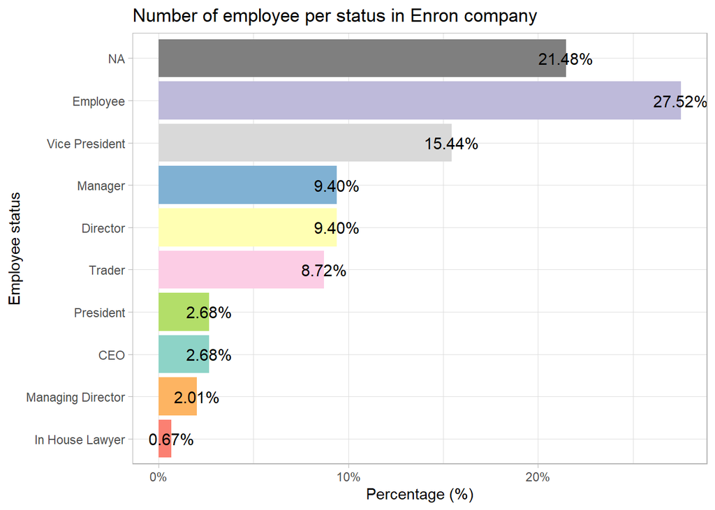

```r
employeelist_2 %>% select(status) %>% #select the needed variable
  group_by(status) %>% count() %>% #count the number of employee per status
  ungroup() %>%
  #calculate the percentage for each status
  mutate(perc = `n`/sum(`n`),
  labels = scales::percent(perc)) %>%
  #bar chart
  ggplot(aes(reorder(status, perc ,sum),perc, fill = status)) +
  geom_bar(stat = "identity") +
  #to invert the axis's position
  coord_flip()+
  #customize the theme, title and axis labels
  geom_text(aes(label = labels), vjust = 0.5, size = 4) + #display the percentage for each category at the end of the corresponding bar
  scale_y_continuous(labels = scales::percent_format())+
  ggtitle("Number of employee per status in Enron company")+
  labs(y = "Percentage (%)",x = "Employee status") +
  scale_fill_brewer(palette = "Set3",
                    #to display the NA in grey on the graph
                    na.value = "grey50")+
  theme(legend.position = "none")
```

### Exploring the email address to see if is it possible to link the table employeelist and df_message through it.

First of all in the df_message we count the distinct email address for the sender and the recipient as well as often they appear in the table:

```r
#count the number of disctint sender email address
sender_count <- df_message %>% select(sender) %>% #keep only the variable we need
  distinct(sender) %>% #keep only once each email address
  count() #count them
```

```r
#count the number of disctint recipient email address
recipient_count <- df_message %>% select(rvalue) %>% distinct(rvalue) %>% count()
```

In the df_message table we observed that their exist 68065 email address for receiver and 17502 for sender. The important difference between them suggesting several are exchange between employee and person outside the company.

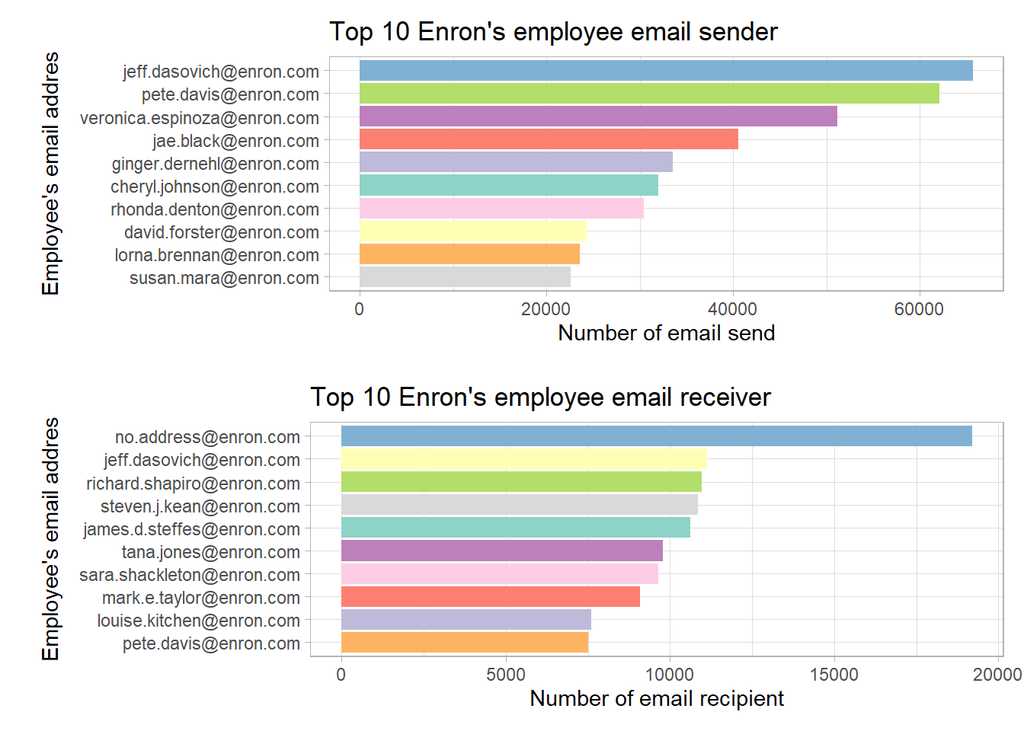

```r
#Display the top 10 email address of sender
p1 <- df_message %>% group_by(sender)%>% count() %>% #to count the number of email send per email address
  arrange(desc(n)) %>% head(10) %>% #to get only the 10 email address with the most important number of email send
  #bar chart
  ggplot(aes(reorder(sender, n, sum), n, fill = sender)) +
  geom_bar(stat="identity") +
  coord_flip() +
  #graph title and label
  labs(title = "Top 10 Enron's employee email sender")+
  xlab("Employee's email addres")+
  ylab("Number of email send") +
  scale_fill_brewer(palette = "Set3")+
    theme(legend.position = "none",
        plot.margin = margin(10, 10, 10, 20))

#Display the top 10 email address of recipient
p2 <- df_message %>% group_by(rvalue)%>% count() %>% #to count the number of email send per email address
  arrange(desc(n)) %>% head(10) %>% #to get only the 10 email address with the most important number of email send
  #bar chart
  ggplot(aes(reorder(rvalue, n, sum), n, fill = rvalue)) +
  geom_bar(stat="identity") +
  coord_flip() +
  #graph title and label
  labs(title = "Top 10 Enron's employee email receiver")+
  xlab("Employee's email addres")+
  ylab("Number of email recipient") +
  scale_fill_brewer(palette = "Set3")+
  theme(legend.position = "none",
        plot.margin = margin(10, 10, 10, 20))

#arrange the plot on the same place
ggarrange(p1, p2,
          nrow=2 )
```

# !!!List of thing need to be achieved !!!

=> merge the employee list with the message DF through the email address

=> for the analysis on employeelist table: - count the number of email address for each employee

=> for the message_df: - look at the number of email per email address - look at the type of email (TO, CC, BC) - look at the number of eamil exchange between month and year -> see if it as significant change around the historic date

=> for the referenceinfo make an analysis of the message content or do it with the subject from recipientinfo table where is more exhaustive. With the subject makes a classification of the potential different type of email send/receive.

=> make a radar chart to display the status and the number of email send/recieve by each. To do it follow this tutorial: https://r-graph-gallery.com/web-circular-barplot-with-R-and-ggplot2.html

=> pursue with the analytics question in the Exam project rules.

=> See if it should be useful to separate the date variable into month and year.

=> see to clean a little the environment to keep in memory only the needed table.